# Homework 6

## Problem 3

**10 points**

Using the code below:

1. Convert both axes to `log10` instead of linear scales.
2. Show axis tick labels as 10^0^, 10^1^, 10^2^,10^3^, 10^4^, 10^5^ for both axes.
3. There are too many points overlapping in certain regions. Use a different `geom_` function to convey to your reader how many overlapping points are present in each region.

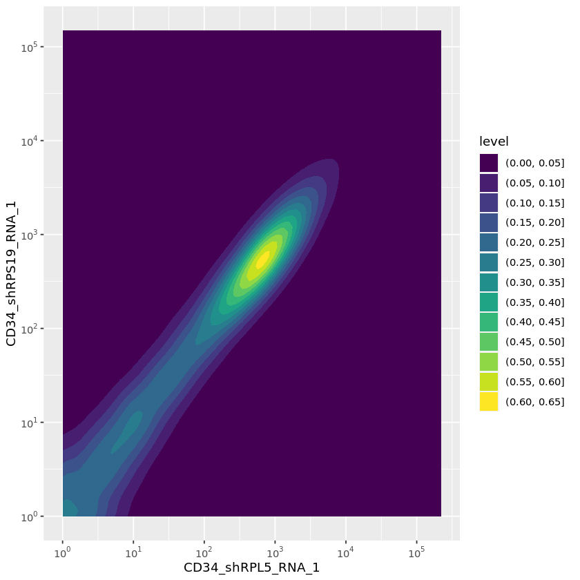

```r
data %>%
  dplyr::select(CD34_shRPL5_RNA_1, CD34_shRPS19_RNA_1) %>%
  ggplot(aes(x = CD34_shRPL5_RNA_1, y = CD34_shRPS19_RNA_1)) +
  # geom_point() +
  # convert axes to log10 and show axis tick labels as 10^0 etc
  scale_x_log10(breaks = c(10^0, 10^1, 10^2, 10^3, 10^4, 10^5), labels=expression(10^0, 10^1, 10^2, 10^3, 10^4, 10^5)) +
  scale_y_log10(breaks = c(10^0, 10^1, 10^2, 10^3, 10^4, 10^5), labels=expression(10^0, 10^1, 10^2, 10^3, 10^4, 10^5)) +
  # use geom_density to show how dense the points are in regions of the plot
  geom_density_2d_filled()
```

**In problems 4 through 6, assign the result of your operation back to the `data` variable.**

## Problem 4

**10 points**

Write a code cell to select the following columns from the `data` variable you created above and reassign back to `data`.

Columns to select: `ensembl_gene_id`, columns that have either `RPL5`, `RPS19`, or `Luc` in their name.

Instead of listing every column, use [`matches`](https://tidyselect.r-lib.org/reference/starts_with.html) and a succinct [regular expression](https://stringr.tidyverse.org/articles/regular-expressions.html) to select the above columns.

```r
data <- data %>%
    dplyr::select(matches("ensembl_gene_id|RPL5|RPS19|Luc")) %>%
    print()
```

```
# A tibble: 63,677 × 13
   ensembl_gene_id CD34_shRPL5_RNA_1 CD34_shRPL5_RNA_2 CD34_shRPL5_RPF_1
   <chr>                       <dbl>             <dbl>             <dbl>
 1 ENSG00000000003                40                49                 6
 2 ENSG00000000005                 0                 0                 0
 3 ENSG00000000419              1116              1000               101
 4 ENSG00000000457               149               126                14
 5 ENSG00000000460               289               268                52
 6 ENSG00000000938               204               145                17
 7 ENSG00000000971               241               203                45
 8 ENSG00000001036              1487               936               182
 9 ENSG00000001084              1036              1224               134
10 ENSG00000001167               498               557                75
# … with 63,667 more rows, and 9 more variables: CD34_shRPL5_RPF_2 <dbl>,
#   CD34_shRPS19_RNA_1 <dbl>, CD34_shRPS19_RNA_2 <dbl>,
#   CD34_shRPS19_RPF_1 <dbl>, CD34_shRPS19_RPF_2 <dbl>, CD34_shLuc_RNA_1 <dbl>,
#   CD34_shLuc_RNA_2 <dbl>, CD34_shLuc_RPF_1 <dbl>, CD34_shLuc_RPF_2 <dbl>
```

## Problem 5

**10 points**

Write a code cell to filter the result from Problem 4 to include only rows where each of the 12 numerical columns you selected has 50 counts or more and reassign back to `data`. This is a simple way to avoid genes that have very low counts.

You might be tempted to do this step separately for each of the 12 columns, but instead use the `across` function you learned above or the `pivot_longer` function from the class (either way is fine).

```r
data <- data %>%
    filter(across(-ensembl_gene_id, ~ .x >= 50)) %>%
    print()
```

[output not shown]

## Problem 6

**10 points**

Write a code cell to divide each of the 12 numerical columns by the corresponding median value for each column and reassign back to `data`. This median normalization is typically done in high-throughput experiments after filtering to normalize for sample-to-sample difference in read depth.

Again, you can write lot less code if you use the `mutate` and `across` function you learned above.

```r
data <- data %>%
    mutate(across(-ensembl_gene_id, ~ .x/median(.x))) %>%
    print()
```

```
# A tibble: 4,185 × 13
   ensembl_gene_id CD34_shRPL5_RNA_1 CD34_shRPL5_RNA_2 CD34_shRPL5_RPF_1
   <chr>                       <dbl>             <dbl>             <dbl>
 1 ENSG00000000419             0.811             0.827             0.612
 2 ENSG00000001036             1.08              0.774             1.10
 3 ENSG00000001084             0.753             1.01              0.812
 4 ENSG00000001497             1.04              1.02              1.53
 5 ENSG00000002549             0.892             0.981             1.73
 6 ENSG00000002586             2.00              1.32              1.58
 7 ENSG00000002834             3.16              3.14              1.54
 8 ENSG00000003056             1.00              1.37              1.95
 9 ENSG00000003393             0.605             0.571             0.509
10 ENSG00000003402             1.33              1.14              0.576
# … with 4,175 more rows, and 9 more variables: CD34_shRPL5_RPF_2 <dbl>,
#   CD34_shRPS19_RNA_1 <dbl>, CD34_shRPS19_RNA_2 <dbl>,
#   CD34_shRPS19_RPF_1 <dbl>, CD34_shRPS19_RPF_2 <dbl>, CD34_shLuc_RNA_1 <dbl>,
#   CD34_shLuc_RNA_2 <dbl>, CD34_shLuc_RPF_1 <dbl>, CD34_shLuc_RPF_2 <dbl>
```

## Problem 7

**10 points**

After we do the above filtering and median-normalization, let us calculate translation efficiency as the average ratio of the RPF and RNA reads for each treatment condition. Then we calculate how this translation efficiency changes between target (`rpl5` and `rps19`) and control (`luc`) shRNAs.

The code implementing the above steps is shown below, but it has a few errors. Correct them.

```r
lfc <- data %>%
  mutate(mean_rpl5_te = ((CD34_shRPL5_RPF_1 + CD34_shRPL5_RPF_2) /
                            (CD34_shRPL5_RNA_1 + CD34_shRPL5_RNA_2))) %>%
  mutate(mean_rps19_te = ((CD34_shRPS19_RPF_1 + CD34_shRPS19_RPF_2) /
                            (CD34_shRPS19_RNA_1 + CD34_shRPS19_RNA_2))) %>%
  mutate(mean_shluc_te = ((CD34_shLuc_RPF_1 + CD34_shLuc_RPF_2) /
                            (CD34_shLuc_RNA_1 + CD34_shLuc_RNA_2))) %>%
  dplyr::select(ensembl_gene_id, mean_rpl5_te, mean_rps19_te, mean_shluc_te) %>%
  mutate(lfc_te_rpl5 = log2(mean_rpl5_te / mean_shluc_te),
         lfc_te_rps19 = log2(mean_rps19_te / mean_shluc_te)) %>%
  print()
```

```
# A tibble: 4,185 × 6
   ensembl_gene_id mean_rpl5_te mean_rps19_te mean_shluc_te lfc_te_rpl5
   <chr>                  <dbl>         <dbl>         <dbl>       <dbl>
 1 ENSG00000000419        0.915         1.48          1.08       -0.244
 2 ENSG00000001036        1.16          1.10          1.45       -0.321
 3 ENSG00000001084        1.01          1.13          0.851       0.253
 4 ENSG00000001497        1.38          1.04          1.75       -0.343
 5 ENSG00000002549        1.77          1.85          1.50        0.241
 6 ENSG00000002586        0.898         0.818         1.13       -0.335
 7 ENSG00000002834        0.477         0.391         0.518      -0.120
 8 ENSG00000003056        1.86          1.85          1.02        0.877
 9 ENSG00000003393        0.827         1.19          0.461       0.842
10 ENSG00000003402        0.502         0.424         0.344       0.547
# … with 4,175 more rows, and 1 more variable: lfc_te_rps19 <dbl>
```

## Problem 8

**10 points**

Write code that will create a new dataframe called `mean_lfc` from `lfc` containing a new column called `avg_lfc`. `avg_lfc` should be the average of the log2 fold-change in TE (`lfc_te`) upon knockdown of RPL5 and RPS19.

Then select only the gene id column and the new column that you just created (this will be your new dataframe `mean_lfc`).

```r
mean_lfc <- lfc %>%
    mutate(avg_lfc = (lfc_te_rpl5 + lfc_te_rps19) / 2 ) %>%
    dplyr::select(ensembl_gene_id, avg_lfc) %>%
    print()
```

```
# A tibble: 4,185 × 2
   ensembl_gene_id avg_lfc
   <chr>             <dbl>
 1 ENSG00000000419   0.104
 2 ENSG00000001036  -0.362
 3 ENSG00000001084   0.330
 4 ENSG00000001497  -0.549
 5 ENSG00000002549   0.273
 6 ENSG00000002586  -0.403
 7 ENSG00000002834  -0.263
 8 ENSG00000003056   0.873
 9 ENSG00000003393   1.11
10 ENSG00000003402   0.424
# … with 4,175 more rows
```

## Problem 9

**10 points**

Write code to join the `mean_lfc` dataframe with the `annotations` dataframe created at the top of the document and assign back to `mean_lfc`.

```r
mean_lfc <- mean_lfc %>%
    left_join(annotations, by = 'ensembl_gene_id') %>%
    print()
```

```
# A tibble: 8,752 × 4
   ensembl_gene_id avg_lfc hgnc_symbol ccds_id
   <chr>             <dbl> <chr>       <chr>
 1 ENSG00000000419   0.104 DPM1        CCDS82628
 2 ENSG00000000419   0.104 DPM1        CCDS13434
 3 ENSG00000000419   0.104 DPM1        CCDS93059
 4 ENSG00000001036  -0.362 FUCA2       CCDS5200
 5 ENSG00000001084   0.330 GCLC        CCDS4952
 6 ENSG00000001084   0.330 GCLC        CCDS75471
 7 ENSG00000001497  -0.549 LAS1L       CCDS55434
 8 ENSG00000001497  -0.549 LAS1L       CCDS14381
 9 ENSG00000001497  -0.549 LAS1L       CCDS55433
10 ENSG00000001497  -0.549 LAS1L       CCDS94622
# … with 8,742 more rows
```

## Problem 10

**10 points**

1. Write code to select only the bottom 10 genes with the lowest `avg_lfc` and display the gene `symbol`, gene `name` and `avg_lfc` for these genes.
2. Create a figure using `ggplot2` to visualize these results.

Write a few sentences to justify the choices you made when creating your figure.

```
# A tibble: 10 × 3
   ensembl_gene_id hgnc_symbol avg_lfc
   <chr>           <chr>         <dbl>
 1 ENSG00000180573 H2AC6         -2.96
 2 ENSG00000197903 H2BC12        -2.80
 3 ENSG00000115268 RPS15         -2.28
 4 ENSG00000176340 COX8A         -2.03
 5 ENSG00000105640 RPL18A        -2.02
 6 ENSG00000137818 RPLP1         -2.02
 7 ENSG00000188486 H2AX          -1.87
 8 ENSG00000197728 RPS26         -1.85
 9 ENSG00000130203 APOE          -1.69
10 ENSG00000148303 RPL7A         -1.69
```

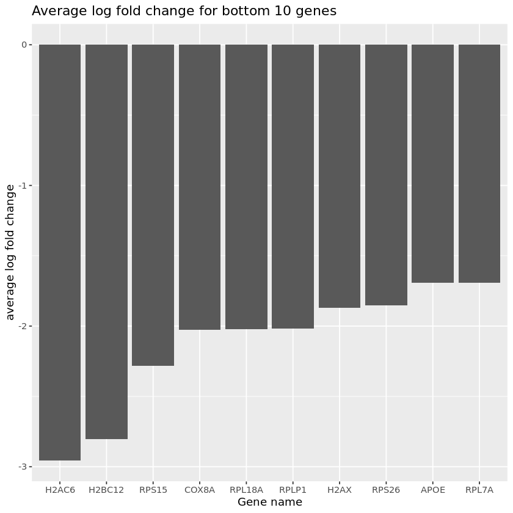

```r
bottom_ten <- mean_lfc %>%
    dplyr::select(ensembl_gene_id, hgnc_symbol, avg_lfc) %>%
    distinct() %>% # needed because the join with annotations introduced some duplicate rows
    slice_min(order_by = avg_lfc, n = 10) %>%
    print()

ggplot(data = bottom_ten, aes(x = fct_reorder(hgnc_symbol, avg_lfc), y = avg_lfc)) +
    geom_col() +
    labs(x = "Gene name", y = "average log fold change", title = "Average log fold change for bottom 10 genes")
```

For the plot, I decided to use a bar plot (geom_col) because the x-axis (gene) is a discrete variable and the y-axis (avg log fold change) is continuous. This makes it easier to see the values than having just points, and a line graph or something like that wouldn't make sense for the data. I plotted the gene names (rather than the ensembl ids) because those are more understandable to the viewer. I also reordered the x-axis using fct_reorder so that they would be displayed in order of log fold change. Finally, I changed the axis labels and title to something more understandable.